# lab10practice

Yasir Ahmad

2023-11-07

## Visualisation practice

Use the newsurvey data obtained by cleaning “na” values in survey data of MASS package to do the following:

```r
library(MASS)
library(ggplot2)
newsurvey = na.omit(survey)
```

1. Plot a bar graph for the number of male and female participants in the survey. Provide the title as “Male and Female participants”, y-axis label as “frequency” and specify the colours for the bars.

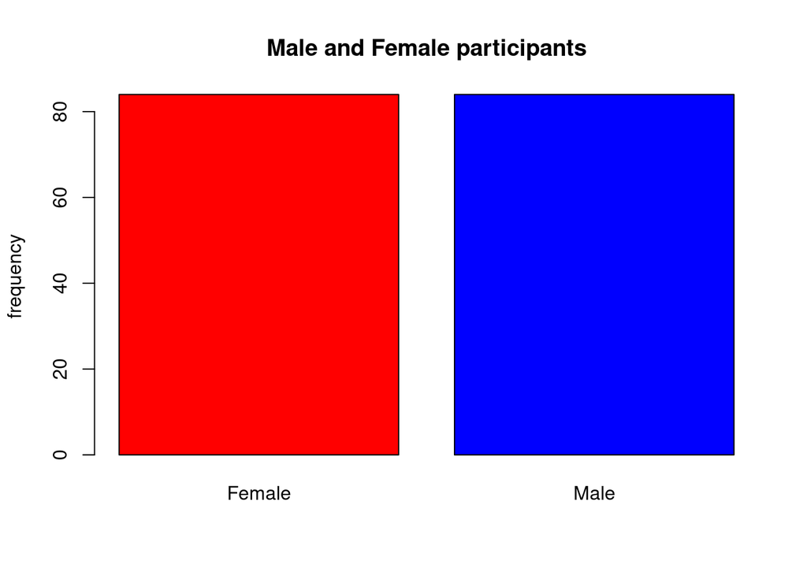

```r
freq = table(newsurvey$Sex)
barplot(freq,main="Male and Female participants", ylab="frequency",col=c('red','blue'))
```

2. Plot a bar graph for the number of left handers and right handers in the survey. Provide the title as “Left Handers and Right Handers”, y-axis label as “count” and specify the colours for the bars

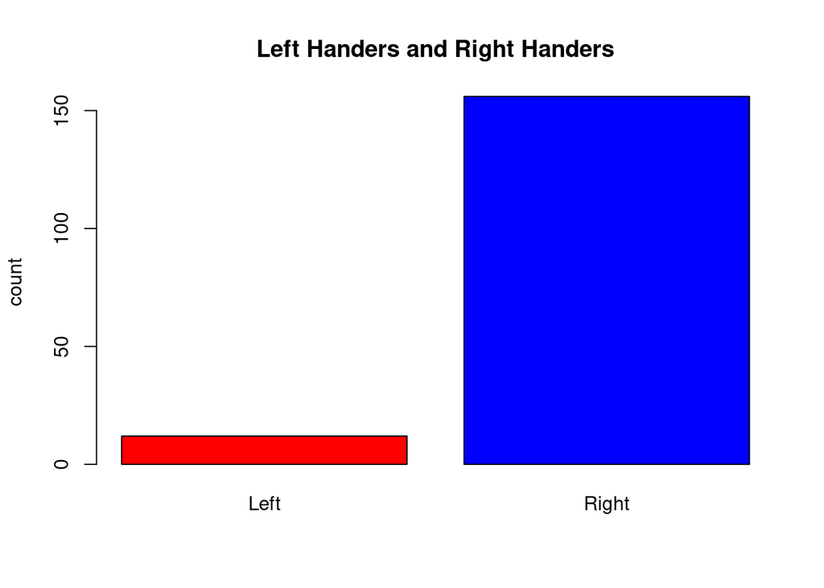

```r
freq = table(newsurvey$W.Hnd)
barplot(freq,main="Left Handers and Right Handers",ylab = "count", col=c("red","blue"))
```

3. Plot the distribution between male left handers and female left handers using bar chart. Provide the title as “Female Left Handers and Male Left Handers , y-axis label as “count” and specify the colours for the bars.

```r
library(dplyr)
```

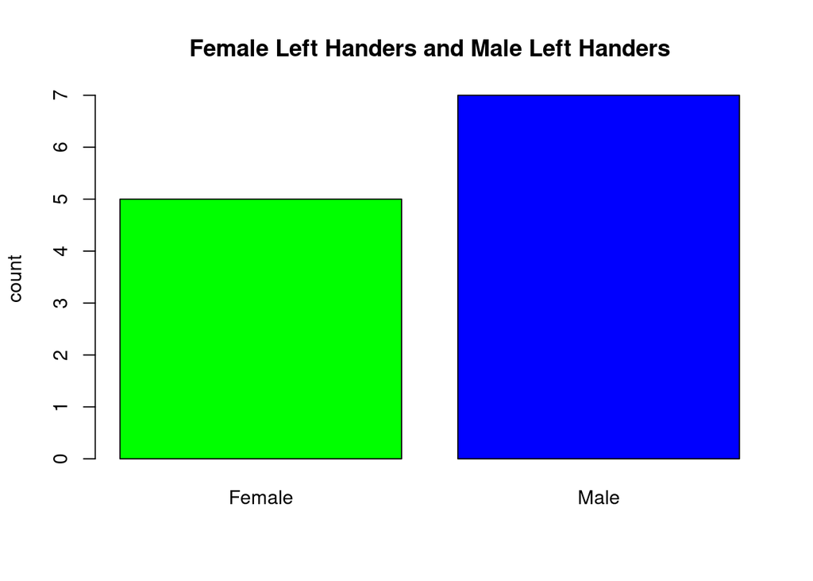

```r
lft_hnders = filter(newsurvey,newsurvey$W.Hnd=="Left")
freq = table(lft_hnders$Sex)
barplot(freq, main="Female Left Handers and Male Left Handers", ylab="count",col = c('green','blue'))
```

4. Draw the histogram of age distribution with the title as „Age distribution‟ and xlabel as „Age range‟ and ylabel as „frequency‟.

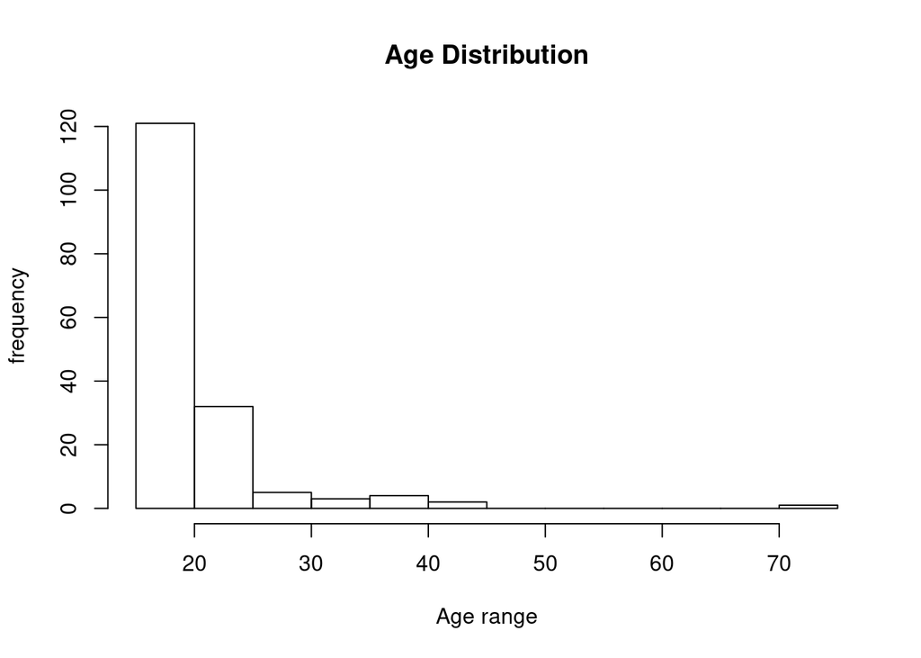

```r
hist(newsurvey$Age,main="Age Distribution",xlab="Age range",ylab="frequency")
```

5. Reveal the relationship between the age and writing hand span using scatter plot.

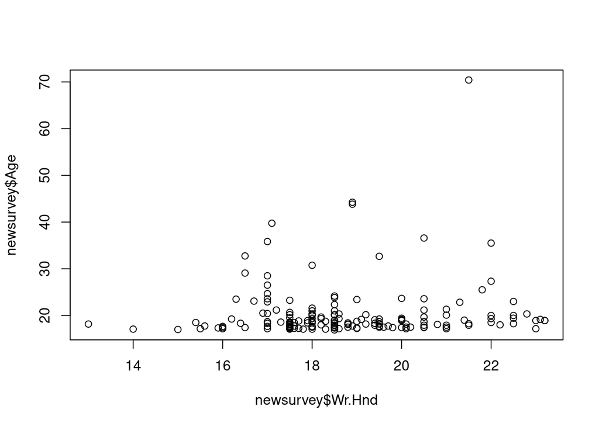

```r
plot(newsurvey$Wr.Hnd,newsurvey$Age)
```

6. Draw the boxplot for pulse rate to analyse the five summary statistics. Provide appropriate title and label.

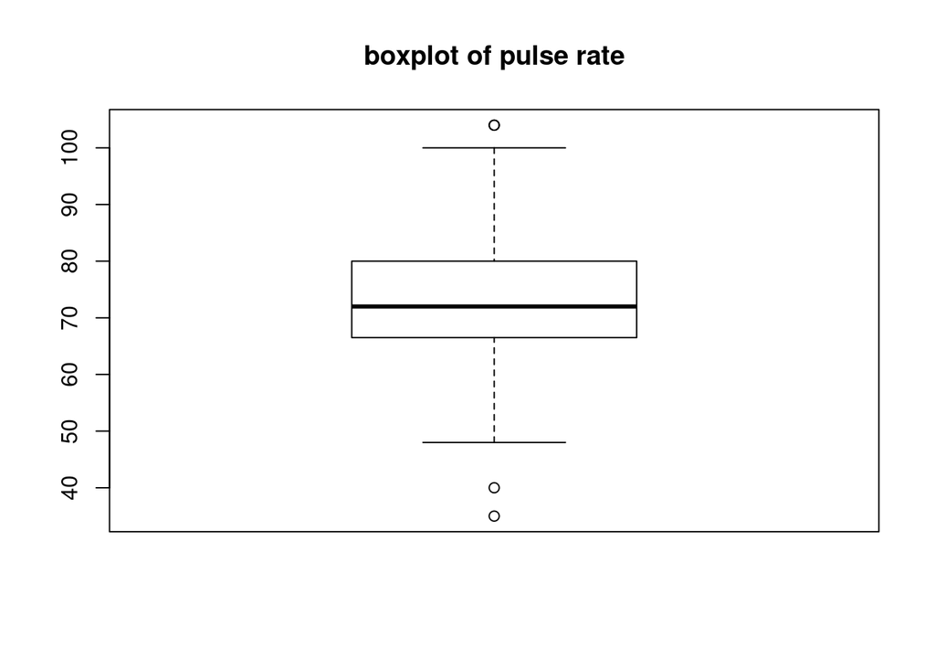

```r
boxplot(newsurvey$Pulse,main="boxplot of pulse rate")
```

```r
summary(newsurvey$Pulse)
```

```
##    Min. 1st Qu.  Median    Mean 3rd Qu.    Max.
##   35.00   66.75   72.00   74.02   80.00  104.00
```

7. Draw the distribution of smoking habits of male left handers using pie chart.

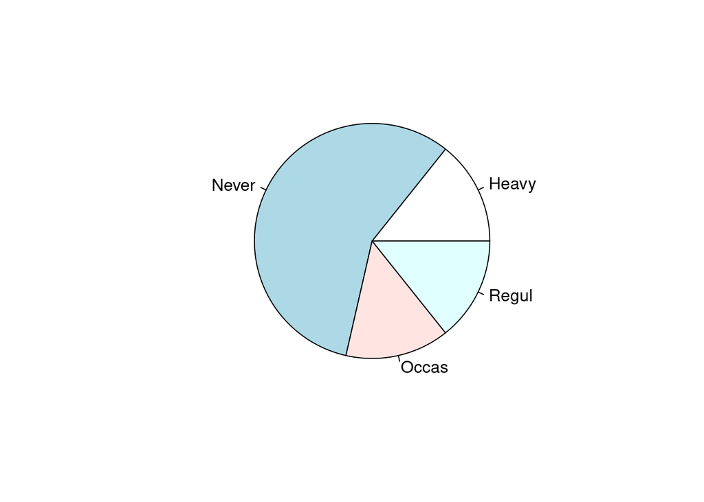

```r
m_L = filter(lft_hnders,lft_hnders$Sex=="Male")
freq = table(m_L$Smoke)
pie(freq)
```

Read iris.csv or weather.csv

```r
data = iris
```

- Apply various visualization techniques.

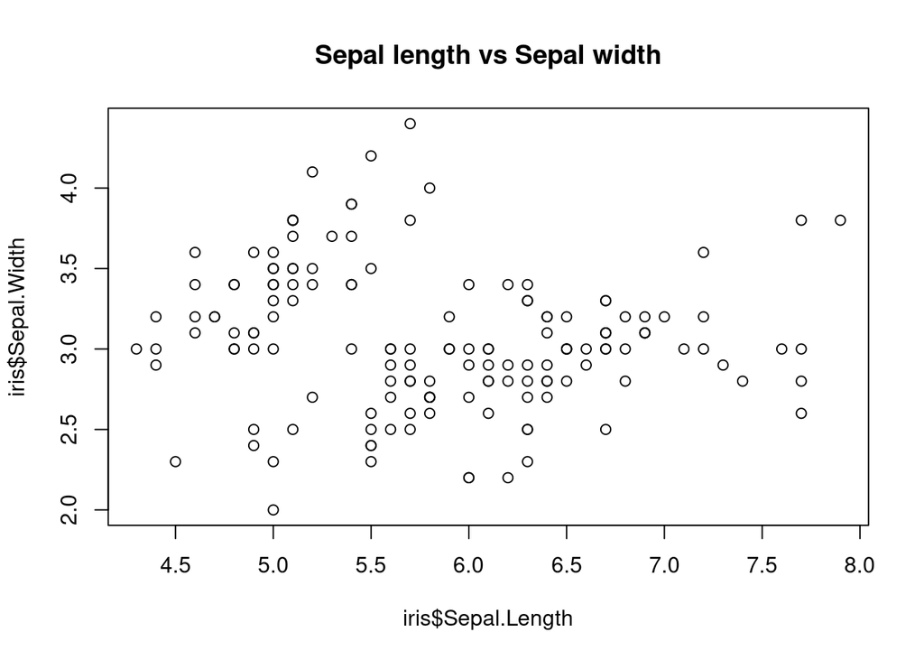

```r
plot(iris$Sepal.Length,iris$Sepal.Width, main="Sepal length vs Sepal width")
```

* Perform correlation analysis and state the inferences

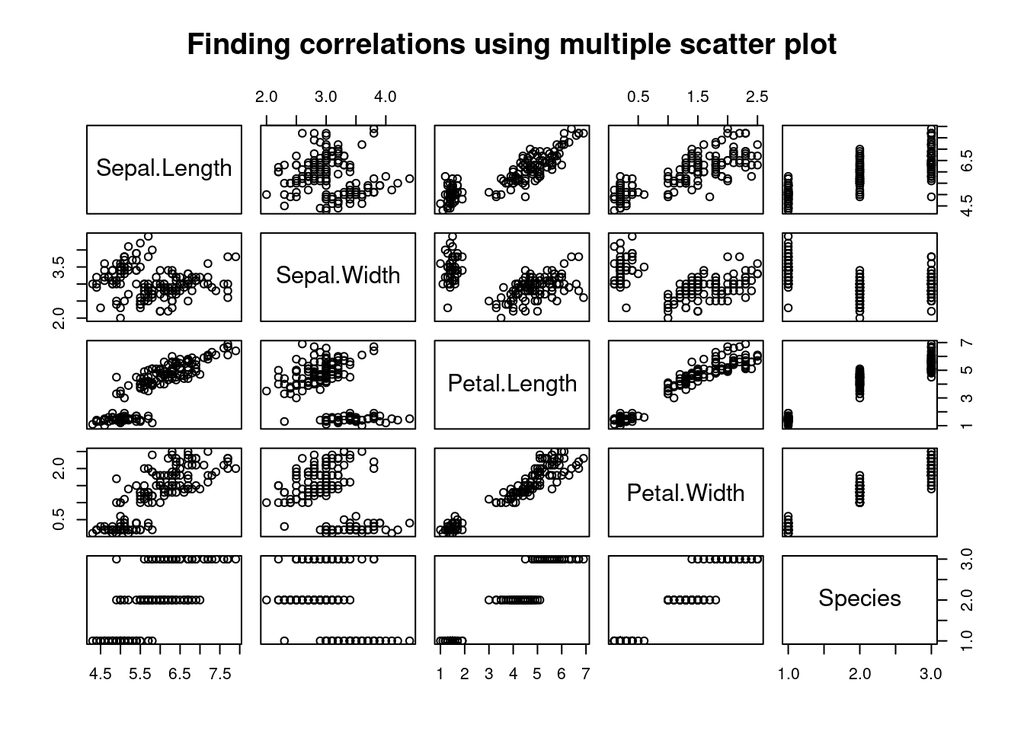

```r
plot(iris, main="Finding correlations using multiple scatter plot")
```

```r
slen_swid = cor(iris$Sepal.Length,iris$Sepal.Width)
slen_plen = cor(iris$Sepal.Length,iris$Petal.Length)
slen_pwid = cor(iris$Sepal.Length,iris$Petal.Width)
swid_plen = cor(iris$Sepal.Width,iris$Petal.Length)
swid_pwid = cor(iris$Sepal.Width,iris$Petal.Width)
plen_pwid = cor(iris$Petal.Length,iris$Petal.Width)

slen_swid
```

```
## [1] -0.1175698
```

```r
slen_plen
```

```
## [1] 0.8717538
```

```r
slen_pwid
```

```
## [1] 0.8179411
```

```r
swid_plen
```

```
## [1] -0.4284401
```

```r
swid_pwid
```

```
## [1] -0.3661259
```

```r
plen_pwid
```

```
## [1] 0.9628654
```

therefore Sepal length and Petal length are positively correlated, Sepal length and Petal width are positively correlated and Petal length and Petal width are positively correlated

- Identify outliers

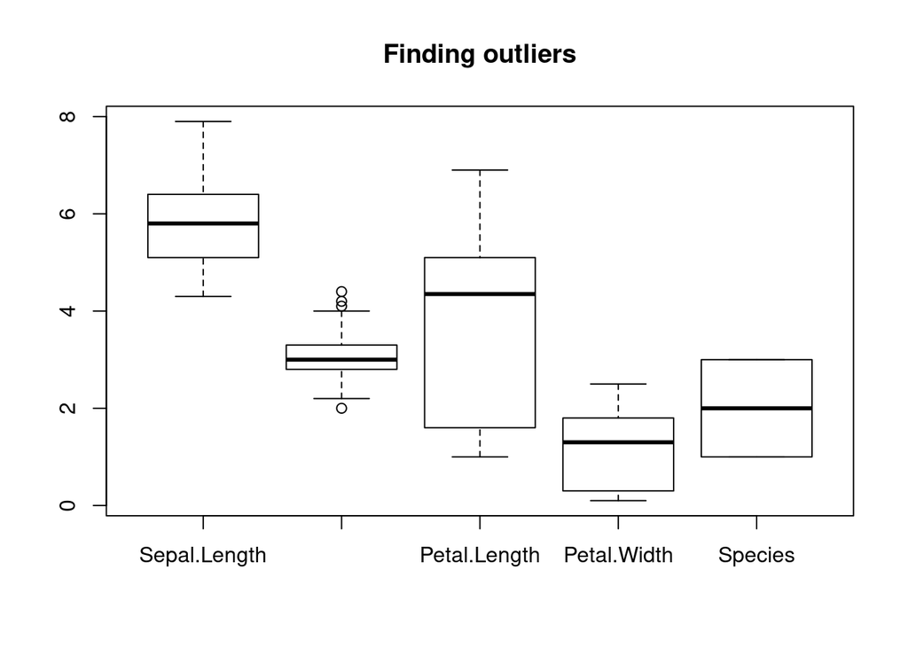

```r
boxplot(iris,main="Finding outliers")
```

- Plot the frequency table

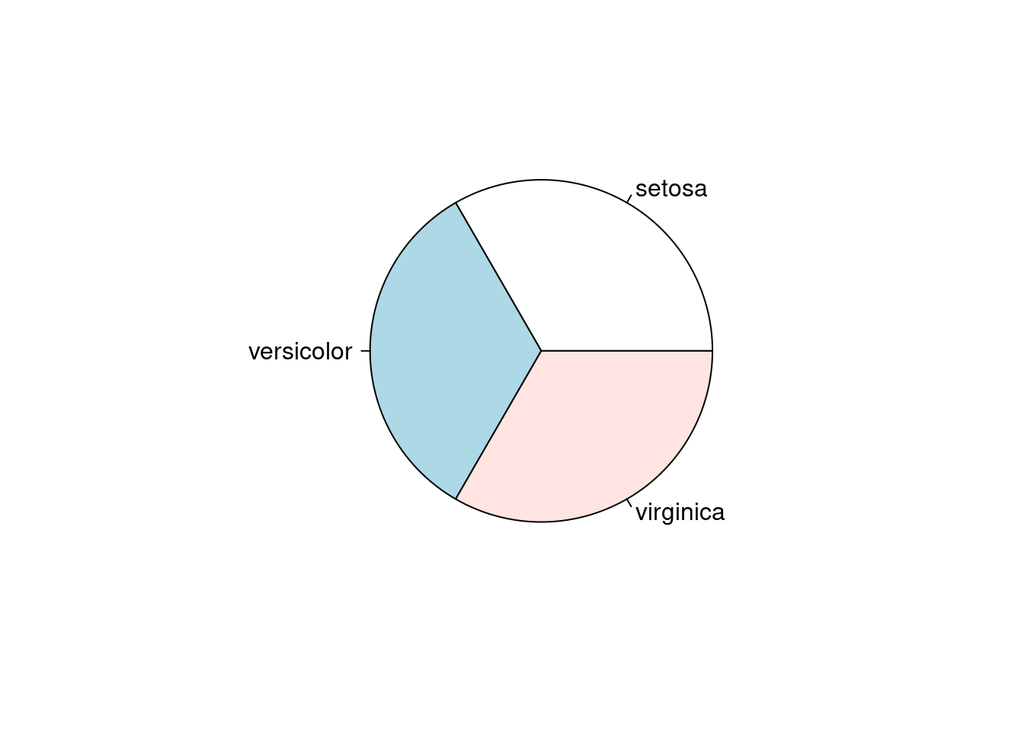

```r
freq = table(iris$Species)
pie(freq)
```